# we have to see entire colums

# we dont need customer id column as it is not related to any of the columns and its of no use in the model making so its better to drop that.

```python
data=data.drop(['customerID'],axis=1)
data.head()
```

|  | gender | SeniorCitizen | Partner | Dependents | tenure | PhoneService | MultipleLines | InternetService | OnlineSecurity | OnlineBackup | DeviceProtection | TechSupport | StreamingTV | StreamingMovies | Contract | PaperlessBilling | PaymentMethod | MonthlyCharges | TotalCharges | Churn |
| --- | --- | --- | --- | --- | --- | --- | --- | --- | --- | --- | --- | --- | --- | --- | --- | --- | --- | --- | --- | --- |
| 0 | Female | 0 | Yes | No | 1 | No | No phone service | DSL | No | Yes | No | No | No | No | Month-to-month | Yes | Electronic check | 29.85 | 29.85 | No |
| 1 | Male | 0 | No | No | 34 | Yes | No | DSL | Yes | No | Yes | No | No | No | One year | No | Mailed check | 56.95 | 1889.5 | No |
| 2 | Male | 0 | No | No | 2 | Yes | No | DSL | Yes | Yes | No | No | No | No | Month-to-month | Yes | Mailed check | 53.85 | 108.15 | Yes |
| 3 | Male | 0 | No | No | 45 | No | No phone service | DSL | Yes | No | Yes | Yes | No | No | One year | No | Bank transfer (automatic) | 42.30 | 1840.75 | No |
| 4 | Female | 0 | No | No | 2 | Yes | No | Fiber optic | No | No | No | No | No | No | Month-to-month | Yes | Electronic check | 70.70 | 151.65 | Yes |

```python
data.info()
```

```
<class 'pandas.core.frame.DataFrame'>
RangeIndex: 7043 entries, 0 to 7042
Data columns (total 20 columns):
 #   Column            Non-Null Count  Dtype
---  ------            --------------  -----
 0   gender            7043 non-null   object
 1   SeniorCitizen     7043 non-null   int64
 2   Partner           7043 non-null   object
 3   Dependents        7043 non-null   object
 4   tenure            7043 non-null   int64
 5   PhoneService      7043 non-null   object
 6   MultipleLines     7043 non-null   object
 7   InternetService   7043 non-null   object
 8   OnlineSecurity    7043 non-null   object
 9   OnlineBackup      7043 non-null   object
 10  DeviceProtection  7043 non-null   object
 11  TechSupport       7043 non-null   object
 12  StreamingTV       7043 non-null   object
 13  StreamingMovies   7043 non-null   object
 14  Contract          7043 non-null   object
 15  PaperlessBilling  7043 non-null   object
 16  PaymentMethod     7043 non-null   object
 17  MonthlyCharges    7043 non-null   float64
 18  TotalCharges      7043 non-null   object
 19  Churn             7043 non-null   object
dtypes: float64(1), int64(2), object(17)
memory usage: 1.1+ MB
```

# from above we need to change total charges column into numeric lets go..

```python
data.TotalCharges=pd.to_numeric(data.TotalCharges,errors='coerce')#errors='coerce' this sets invalid data into Nan values
data.info()
```

```
<class 'pandas.core.frame.DataFrame'>
RangeIndex: 7043 entries, 0 to 7042
Data columns (total 20 columns):
 #   Column            Non-Null Count  Dtype
---  ------            --------------  -----
 0   gender            7043 non-null   object
 1   SeniorCitizen     7043 non-null   int64
 2   Partner           7043 non-null   object
 3   Dependents        7043 non-null   object
 4   tenure            7043 non-null   int64
 5   PhoneService      7043 non-null   object
 6   MultipleLines     7043 non-null   object
 7   InternetService   7043 non-null   object
 8   OnlineSecurity    7043 non-null   object
 9   OnlineBackup      7043 non-null   object
 10  DeviceProtection  7043 non-null   object
 11  TechSupport       7043 non-null   object
 12  StreamingTV       7043 non-null   object
 13  StreamingMovies   7043 non-null   object
 14  Contract          7043 non-null   object
 15  PaperlessBilling  7043 non-null   object
 16  PaymentMethod     7043 non-null   object
 17  MonthlyCharges    7043 non-null   float64
 18  TotalCharges      7032 non-null   float64
 19  Churn             7043 non-null   object
dtypes: float64(2), int64(2), object(16)
memory usage: 1.1+ MB
```

# Now You all can see that total charges column is converted to float which is numeric

# Now lets check null values

```python
data.isnull().sum()
```

```
gender               0
SeniorCitizen        0
Partner              0
Dependents           0
tenure               0
PhoneService         0
MultipleLines        0
InternetService      0
OnlineSecurity       0
OnlineBackup         0
DeviceProtection     0
TechSupport          0
StreamingTV          0
StreamingMovies      0
Contract             0
PaperlessBilling     0
PaymentMethod        0
MonthlyCharges       0
TotalCharges        11
Churn                0
dtype: int64
```

# From the above output we can infer that totalcharge column has 11 null values out of 7000 entries ther's no problem removing null values from this column

```python
data.dropna(inplace=True)
data.head()
```

|  | gender | SeniorCitizen | Partner | Dependents | tenure | PhoneService | MultipleLines | InternetService | OnlineSecurity | OnlineBackup | DeviceProtection | TechSupport | StreamingTV | StreamingMovies | Contract | PaperlessBilling | PaymentMethod | MonthlyCharges | TotalCharges | Churn |
| --- | --- | --- | --- | --- | --- | --- | --- | --- | --- | --- | --- | --- | --- | --- | --- | --- | --- | --- | --- | --- |
| 0 | Female | 0 | Yes | No | 1 | No | No phone service | DSL | No | Yes | No | No | No | No | Month-to-month | Yes | Electronic check | 29.85 | 29.85 | No |
| 1 | Male | 0 | No | No | 34 | Yes | No | DSL | Yes | No | Yes | No | No | No | One year | No | Mailed check | 56.95 | 1889.50 | No |
| 2 | Male | 0 | No | No | 2 | Yes | No | DSL | Yes | Yes | No | No | No | No | Month-to-month | Yes | Mailed check | 53.85 | 108.15 | Yes |
| 3 | Male | 0 | No | No | 45 | No | No phone service | DSL | Yes | No | Yes | Yes | No | No | One year | No | Bank transfer (automatic) | 42.30 | 1840.75 | No |
| 4 | Female | 0 | No | No | 2 | Yes | No | Fiber optic | No | No | No | No | No | No | Month-to-month | Yes | Electronic check | 70.70 | 151.65 | Yes |

## Converting categorical columns into Binary using get dummies

## but first we need to convert churn column from string to binary by replacing yes=1 and no=0

```python
data['Churn'].replace('Yes',1, inplace=True)
data['Churn'].replace('No',0, inplace=True)
```

```python
data1=pd.get_dummies(data)
df=data1
data1.head(50)

#df=data_complete.head(1500)
```

|  | SeniorCitizen | tenure | MonthlyCharges | TotalCharges | Churn | gender_Female | gender_Male | Partner_No | Partner_Yes | Dependents_No | Dependents_Yes | PhoneService_No | PhoneService_Yes | MultipleLines_No | MultipleLines_No phone service | MultipleLines_Yes | InternetService_DSL | InternetService_Fiber optic | InternetService_No | OnlineSecurity_No | OnlineSecurity_No internet service | OnlineSecurity_Yes | OnlineBackup_No | OnlineBackup_No internet service | OnlineBackup_Yes | DeviceProtection_No | DeviceProtection_No internet service | DeviceProtection_Yes | TechSupport_No | … |
| --- | --- | --- | --- | --- | --- | --- | --- | --- | --- | --- | --- | --- | --- | --- | --- | --- | --- | --- | --- | --- | --- | --- | --- | --- | --- | --- | --- | --- | --- | --- |
| 0 | 0 | 1 | 29.85 | 29.85 | 0 | True | False | False | True | True | False | True | False | False | True | False | True | False | False | True | False | False | False | False | True | True | False | False | True | … |
| 1 | 0 | 34 | 56.95 | 1889.50 | 0 | False | True | True | False | True | False | False | True | True | False | False | True | False | False | False | False | True | True | False | False | False | False | True | True | … |
| 2 | 0 | 2 | 53.85 | 108.15 | 1 | False | True | True | False | True | False | False | True | True | False | False | True | False | False | False | False | True | False | False | True | True | False | False | True | … |
| 3 | 0 | 45 | 42.30 | 1840.75 | 0 | False | True | True | False | True | False | True | False | False | True | False | True | False | False | False | False | True | True | False | False | False | False | True | False | … |
| 4 | 0 | 2 | 70.70 | 151.65 | 1 | True | False | True | False | True | False | False | True | True | False | False | False | True | False | True | False | False | True | False | False | True | False | False | True | … |
| 5 | 0 | 8 | 99.65 | 820.50 | 1 | True | False | True | False | True | False | False | True | False | False | True | False | True | False | True | False | False | True | False | False | False | False | True | True | … |
| 6 | 0 | 22 | 89.10 | 1949.40 | 0 | False | True | True | False | False | True | False | True | False | False | True | False | True | False | True | False | False | False | False | True | True | False | False | True | … |
| 7 | 0 | 10 | 29.75 | 301.90 | 0 | True | False | True | False | True | False | True | False | False | True | False | True | False | False | False | False | True | True | False | False | True | False | False | True | … |
| 8 | 0 | 28 | 104.80 | 3046.05 | 1 | True | False | False | True | True | False | False | True | False | False | True | False | True | False | True | False | False | True | False | False | False | False | True | False | … |
| 9 | 0 | 62 | 56.15 | 3487.95 | 0 | False | True | True | False | False | True | False | True | True | False | False | True | False | False | False | False | True | False | False | True | True | False | False | True | … |
| 10 | 0 | 13 | 49.95 | 587.45 | 0 | False | True | False | True | False | True | False | True | True | False | False | True | False | False | False | False | True | True | False | False | True | False | False | True | … |
| 11 | 0 | 16 | 18.95 | 326.80 | 0 | False | True | True | False | True | False | False | True | True | False | False | False | False | True | False | True | False | False | True | False | False | True | False | False | … |
| 12 | 0 | 58 | 100.35 | 5681.10 | 0 | False | True | False | True | True | False | False | True | False | False | True | False | True | False | True | False | False | True | False | False | False | False | True | True | … |
| 13 | 0 | 49 | 103.70 | 5036.30 | 1 | False | True | True | False | True | False | False | True | False | False | True | False | True | False | True | False | False | False | False | True | False | False | True | True | … |
| 14 | 0 | 25 | 105.50 | 2686.05 | 0 | False | True | True | False | True | False | False | True | True | False | False | False | True | False | False | False | True | True | False | False | False | False | True | False | … |
| 15 | 0 | 69 | 113.25 | 7895.15 | 0 | True | False | False | True | False | True | False | True | False | False | True | False | True | False | False | False | True | False | False | True | False | False | True | False | … |
| 16 | 0 | 52 | 20.65 | 1022.95 | 0 | True | False | True | False | True | False | False | True | True | False | False | False | False | True | False | True | False | False | True | False | False | True | False | False | … |
| 17 | 0 | 71 | 106.70 | 7382.25 | 0 | False | True | True | False | False | True | False | True | False | False | True | False | True | False | False | False | True | True | False | False | False | False | True | True | … |
| 18 | 0 | 10 | 55.20 | 528.35 | 1 | True | False | False | True | False | True | False | True | True | False | False | True | False | False | True | False | False | True | False | False | False | False | True | False | … |
| 19 | 0 | 21 | 90.05 | 1862.90 | 0 | True | False | True | False | True | False | False | True | True | False | False | False | True | False | True | False | False | False | False | True | False | False | True | True | … |
| 20 | 1 | 1 | 39.65 | 39.65 | 1 | False | True | True | False | True | False | True | False | False | True | False | True | False | False | True | False | False | True | False | False | False | False | True | True | … |
| 21 | 0 | 12 | 19.80 | 202.25 | 0 | False | True | False | True | True | False | False | True | True | False | False | False | False | True | False | True | False | False | True | False | False | True | False | False | … |
| 22 | 0 | 1 | 20.15 | 20.15 | 1 | False | True | True | False | True | False | False | True | True | False | False | False | False | True | False | True | False | False | True | False | False | True | False | False | … |
| 23 | 0 | 58 | 59.90 | 3505.10 | 0 | True | False | False | True | True | False | False | True | False | False | True | True | False | False | True | False | False | False | False | True | True | False | False | False | … |
| 24 | 0 | 49 | 59.60 | 2970.30 | 0 | False | True | False | True | False | True | False | True | True | False | False | True | False | False | False | False | True | False | False | True | True | False | False | False | … |
| 25 | 0 | 30 | 55.30 | 1530.60 | 0 | True | False | True | False | True | False | False | True | True | False | False | True | False | False | False | False | True | False | False | True | True | False | False | True | … |
| 26 | 0 | 47 | 99.35 | 4749.15 | 1 | False | True | False | True | False | True | False | True | False | False | True | False | True | False | True | False | False | False | False | True | True | False | False | True | … |
| 27 | 0 | 1 | 30.20 | 30.20 | 1 | False | True | False | True | False | True | True | False | False | True | False | True | False | False | True | False | False | False | False | True | True | False | False | True | … |
| 28 | 0 | 72 | 90.25 | 6369.45 | 0 | False | True | False | True | True | False | False | True | False | False | True | True | False | False | False | False | True | False | False | True | False | False | True | False | … |
| 29 | 0 | 17 | 64.70 | 1093.10 | 1 | True | False | True | False | False | True | False | True | True | False | False | True | False | False | True | False | False | True | False | False | True | False | False | True | … |
| 30 | 1 | 71 | 96.35 | 6766.95 | 0 | True | False | False | True | True | False | False | True | False | False | True | False | True | False | False | False | True | False | False | True | False | False | True | False | … |
| 31 | 1 | 2 | 95.50 | 181.65 | 0 | False | True | False | True | True | False | False | True | True | False | False | False | True | False | True | False | False | True | False | False | False | False | True | True | … |
| 32 | 0 | 27 | 66.15 | 1874.45 | 0 | True | False | False | True | False | True | False | True | True | False | False | True | False | False | False | False | True | False | False | True | False | False | True | False | … |
| 33 | 0 | 1 | 20.20 | 20.20 | 0 | False | True | True | False | True | False | False | True | True | False | False | False | False | True | False | True | False | False | True | False | False | True | False | False | … |
| 34 | 1 | 1 | 45.25 | 45.25 | 0 | False | True | True | False | True | False | False | True | True | False | False | True | False | False | True | False | False | True | False | False | True | False | False | True | … |
| 35 | 0 | 72 | 99.90 | 7251.70 | 0 | True | False | False | True | False | True | False | True | False | False | True | False | True | False | False | False | True | False | False | True | True | False | False | False | … |
| 36 | 0 | 5 | 69.70 | 316.90 | 1 | False | True | True | False | True | False | False | True | True | False | False | False | True | False | True | False | False | True | False | False | True | False | False | True | … |
| 37 | 0 | 46 | 74.80 | 3548.30 | 0 | True | False | True | False | True | False | False | True | True | False | False | False | True | False | True | False | False | True | False | False | False | False | True | True | … |
| 38 | 0 | 34 | 106.35 | 3549.25 | 1 | False | True | True | False | True | False | False | True | False | False | True | False | True | False | True | False | False | False | False | True | False | False | True | True | … |
| 39 | 0 | 11 | 97.85 | 1105.40 | 1 | True | False | True | False | True | False | False | True | False | False | True | False | True | False | True | False | False | True | False | False | False | False | True | True | … |
| 40 | 0 | 10 | 49.55 | 475.70 | 0 | False | True | False | True | False | True | False | True | True | False | False | True | False | False | True | False | False | False | False | True | True | False | False | True | … |
| 41 | 0 | 70 | 69.20 | 4872.35 | 0 | True | False | False | True | False | True | False | True | False | False | True | True | False | False | False | False | True | False | False | True | True | False | False | True | … |
| 42 | 0 | 17 | 20.75 | 418.25 | 0 | True | False | False | True | False | True | False | True | True | False | False | False | False | True | False | True | False | False | True | False | False | True | False | False | … |
| 43 | 0 | 63 | 79.85 | 4861.45 | 0 | True | False | True | False | True | False | False | True | False | False | True | True | False | False | False | False | True | False | False | True | False | False | True | False | … |
| 44 | 0 | 13 | 76.20 | 981.45 | 0 | True | False | False | True | True | False | False | True | False | False | True | True | False | False | False | False | True | False | False | True | True | False | False | False | … |
| 45 | 0 | 49 | 84.50 | 3906.70 | 0 | True | False | True | False | True | False | False | True | False | False | True | False | True | False | True | False | False | True | False | False | True | False | False | True | … |
| 46 | 0 | 2 | 49.25 | 97.00 | 0 | False | True | True | False | True | False | False | True | True | False | False | True | False | False | True | False | False | False | False | True | True | False | False | True | … |
| 47 | 0 | 2 | 80.65 | 144.15 | 1 | True | False | True | False | True | False | False | True | True | False | False | False | True | False | True | False | False | True | False | False | True | False | False | True | … |
| 48 | 0 | 52 | 79.75 | 4217.80 | 0 | False | True | True | False | True | False | False | True | False | False | True | True | False | False | False | False | True | True | False | False | True | False | False | False | … |
| 49 | 0 | 69 | 64.15 | 4254.10 | 0 | True | False | False | True | False | True | False | True | False | False | True | True | False | False | False | False | True | True | False | False | False | False | True | False | … |

# as you can see that our categorical colmuns has been converte dbt htere is one problem its in TRUE and FALSE values we need it in 0's and 1's lets convert them

```python
df.replace({True: 1, False:0},inplace=True)
df.head()
```

|  | SeniorCitizen | tenure | MonthlyCharges | TotalCharges | Churn | gender_Female | gender_Male | Partner_No | Partner_Yes | Dependents_No | Dependents_Yes | PhoneService_No | PhoneService_Yes | MultipleLines_No | MultipleLines_No phone service | MultipleLines_Yes | InternetService_DSL | InternetService_Fiber optic | InternetService_No | OnlineSecurity_No | OnlineSecurity_No internet service | OnlineSecurity_Yes | OnlineBackup_No | OnlineBackup_No internet service | OnlineBackup_Yes | DeviceProtection_No | DeviceProtection_No internet service | DeviceProtection_Yes | TechSupport_No | … |
| --- | --- | --- | --- | --- | --- | --- | --- | --- | --- | --- | --- | --- | --- | --- | --- | --- | --- | --- | --- | --- | --- | --- | --- | --- | --- | --- | --- | --- | --- | --- |
| 0 | 0 | 1 | 29.85 | 29.85 | 0 | 1 | 0 | 0 | 1 | 1 | 0 | 1 | 0 | 0 | 1 | 0 | 1 | 0 | 0 | 1 | 0 | 0 | 0 | 0 | 1 | 1 | 0 | 0 | 1 | … |
| 1 | 0 | 34 | 56.95 | 1889.50 | 0 | 0 | 1 | 1 | 0 | 1 | 0 | 0 | 1 | 1 | 0 | 0 | 1 | 0 | 0 | 0 | 0 | 1 | 1 | 0 | 0 | 0 | 0 | 1 | 1 | … |
| 2 | 0 | 2 | 53.85 | 108.15 | 1 | 0 | 1 | 1 | 0 | 1 | 0 | 0 | 1 | 1 | 0 | 0 | 1 | 0 | 0 | 0 | 0 | 1 | 0 | 0 | 1 | 1 | 0 | 0 | 1 | … |
| 3 | 0 | 45 | 42.30 | 1840.75 | 0 | 0 | 1 | 1 | 0 | 1 | 0 | 1 | 0 | 0 | 1 | 0 | 1 | 0 | 0 | 0 | 0 | 1 | 1 | 0 | 0 | 0 | 0 | 1 | 0 | … |
| 4 | 0 | 2 | 70.70 | 151.65 | 1 | 1 | 0 | 1 | 0 | 1 | 0 | 0 | 1 | 1 | 0 | 0 | 0 | 1 | 0 | 1 | 0 | 0 | 1 | 0 | 0 | 1 | 0 | 0 | 1 | … |

# lets divide customers into categories based on tenure e.g. for tenure < 12 months: assign a tenure group if 1-12, for tenure between 1 to 2 Yrs, tenure group of 13-24; so on...

# for that we need to finf max tenure

```python
print(data1['tenure'].max())
```

```
72
```

```python
labels=['{0}-{1}'.format(i,i+11) for i in range(1, 72, 12)] # grouped tenure in the groups or bins of 12
```

```python
data['tenure_group'] = pd.cut(data1.tenure, range(1, 80, 12), right=False, labels=labels)
data['tenure_group']
```

```
0        1-12
1       25-36
2        1-12
3       37-48
4        1-12
        ...
7038    13-24
7039    61-72
7040     1-12
7041     1-12
7042    61-72
Name: tenure_group, Length: 7032, dtype: category
Categories (6, object): ['1-12' < '13-24' < '25-36' < '37-48' < '49-60' < '61-72']
```

# lets count how many customers belong to which categories

```python
data['tenure_group'].value_counts()
```

```
tenure_group
1-12     2175
61-72    1407
13-24    1024
25-36     832
49-60     832
37-48     762
Name: count, dtype: int64
```

# now we can remove unwanted columns such as tenure

## now question arises why tenure ? because we have made our own column name tenure_group so we now we dont need tenure column if we keep it it will be confusing for us

### till nw we dropped 2 columns (Customer id and Tenure)

```python
data1.drop(columns=['tenure'],axis=1,inplace=True)
data1.head()
```

|  | SeniorCitizen | MonthlyCharges | TotalCharges | Churn | gender_Female | gender_Male | Partner_No | Partner_Yes | Dependents_No | Dependents_Yes | PhoneService_No | PhoneService_Yes | MultipleLines_No | MultipleLines_No phone service | MultipleLines_Yes | InternetService_DSL | InternetService_Fiber optic | InternetService_No | OnlineSecurity_No | OnlineSecurity_No internet service | OnlineSecurity_Yes | OnlineBackup_No | OnlineBackup_No internet service | OnlineBackup_Yes | DeviceProtection_No | DeviceProtection_No internet service | DeviceProtection_Yes | TechSupport_No | TechSupport_No internet service | … |
| --- | --- | --- | --- | --- | --- | --- | --- | --- | --- | --- | --- | --- | --- | --- | --- | --- | --- | --- | --- | --- | --- | --- | --- | --- | --- | --- | --- | --- | --- | --- |
| 0 | 0 | 29.85 | 29.85 | 0 | 1 | 0 | 0 | 1 | 1 | 0 | 1 | 0 | 0 | 1 | 0 | 1 | 0 | 0 | 1 | 0 | 0 | 0 | 0 | 1 | 1 | 0 | 0 | 1 | 0 | … |
| 1 | 0 | 56.95 | 1889.50 | 0 | 0 | 1 | 1 | 0 | 1 | 0 | 0 | 1 | 1 | 0 | 0 | 1 | 0 | 0 | 0 | 0 | 1 | 1 | 0 | 0 | 0 | 0 | 1 | 1 | 0 | … |
| 2 | 0 | 53.85 | 108.15 | 1 | 0 | 1 | 1 | 0 | 1 | 0 | 0 | 1 | 1 | 0 | 0 | 1 | 0 | 0 | 0 | 0 | 1 | 0 | 0 | 1 | 1 | 0 | 0 | 1 | 0 | … |
| 3 | 0 | 42.30 | 1840.75 | 0 | 0 | 1 | 1 | 0 | 1 | 0 | 1 | 0 | 0 | 1 | 0 | 1 | 0 | 0 | 0 | 0 | 1 | 1 | 0 | 0 | 0 | 0 | 1 | 0 | 0 | … |
| 4 | 0 | 70.70 | 151.65 | 1 | 1 | 0 | 1 | 0 | 1 | 0 | 0 | 1 | 1 | 0 | 0 | 0 | 1 | 0 | 1 | 0 | 0 | 1 | 0 | 0 | 1 | 0 | 0 | 1 | 0 | … |

# lets plot every column with respect to churn

## this is part of data exploration

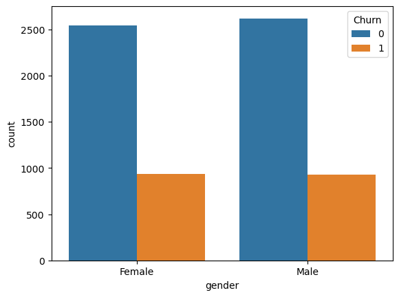

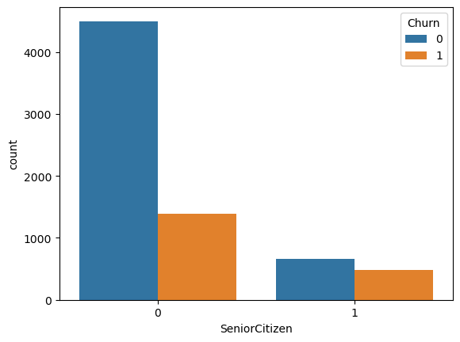

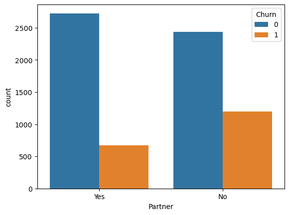

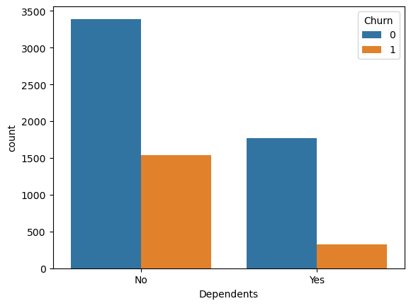

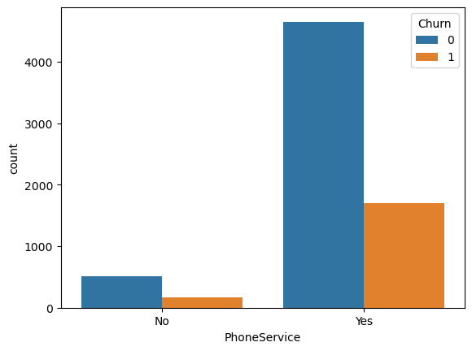

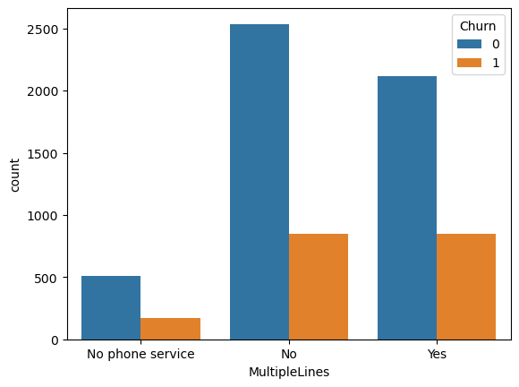

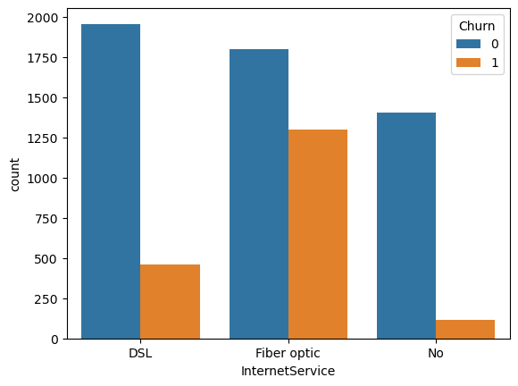

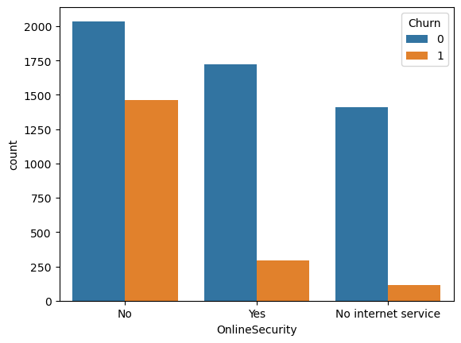

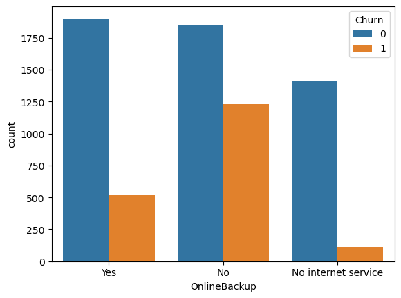

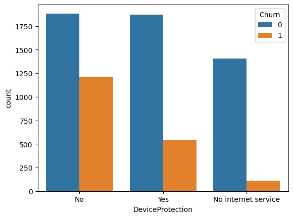

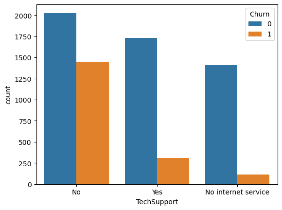

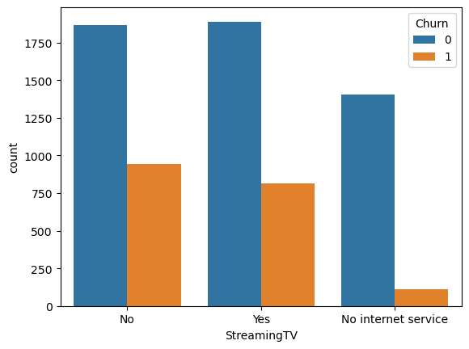

[5 more figures not shown]

```python
for i, predictor in enumerate(data.drop(columns=['Churn','TotalCharges','MonthlyCharges'])):
    plt.figure(i)
    sns.countplot(x=predictor,data=data,hue='Churn')
```

# lets check relationship between monthly charges and totla charges

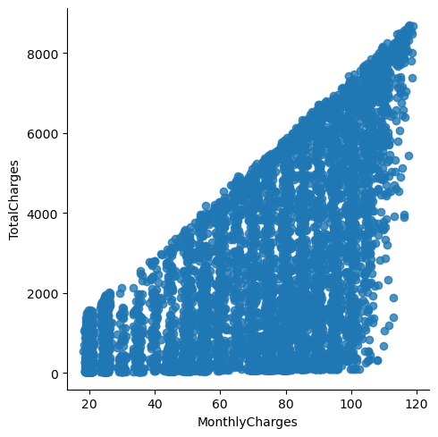

```python
sns.lmplot(x='MonthlyCharges',y='TotalCharges',data=data1,fit_reg=False) # used data1 as data because if we use original data then we will get an absolute value or outlier because categorical values are not converted into binary
```